# Algoritmos Genéticos x Força Bruta para seleção de modelos de regressão

### Algoritmos Genéticos

```
Initialization...
TASK: Genetic algorithm in the candidate set.
Initialization...
Algorithm started...

After 10 generations:
Best model: mpg~1+hp+wt+qsec+qsec:drat+qsec:wt+gear:hp+gear:wt+gear:qsec
Crit= 138.975661358302
Mean crit= 151.182613166538
```

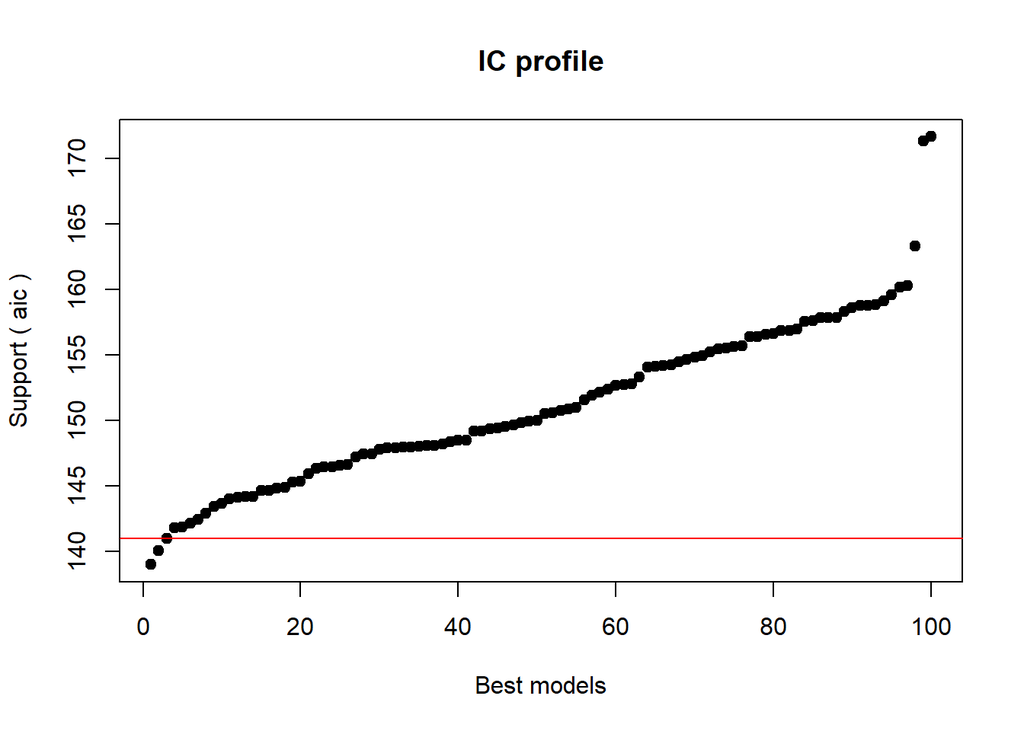

```
Change in best IC: -9861.0243386417 / Change in mean IC: -9848.81738683346

After 20 generations:
Best model: mpg~1+hp+wt+qsec+qsec:wt+gear:hp+gear:wt+gear:qsec
Crit= 137.952546857568
Mean crit= 149.035616345581
```

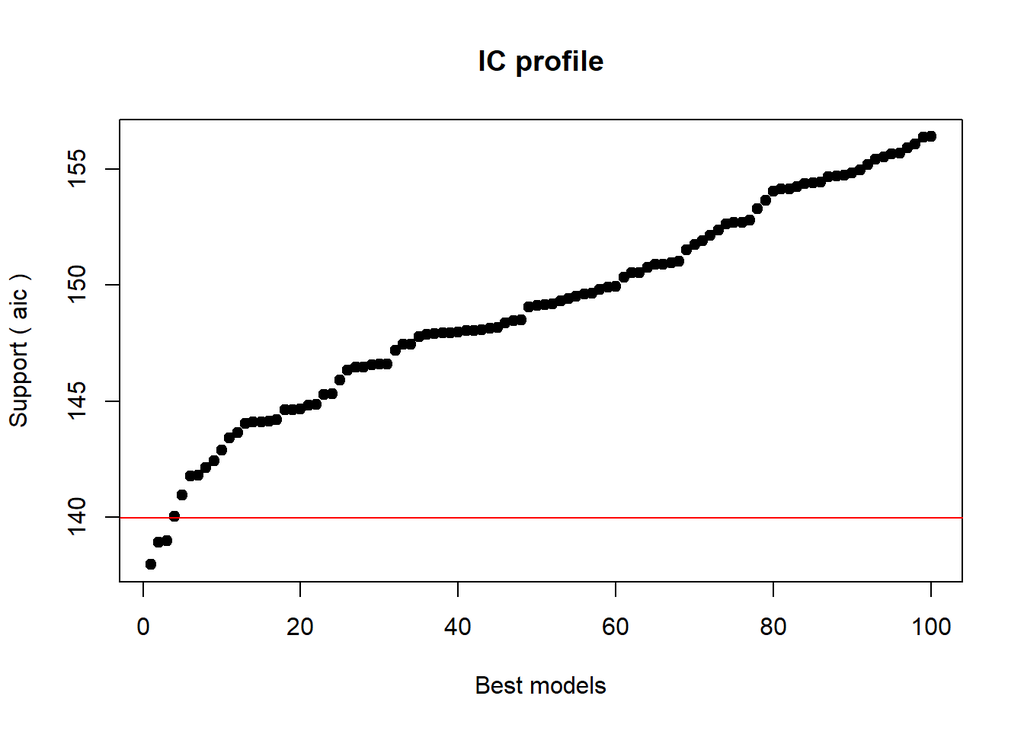

```
Change in best IC: -1.02311450073427 / Change in mean IC: -2.14699682095701

After 30 generations:
Best model: mpg~1+wt+qsec+gear+qsec:hp+qsec:wt+gear:drat+gear:wt
Crit= 136.61102526519
Mean crit= 147.398777170023
```

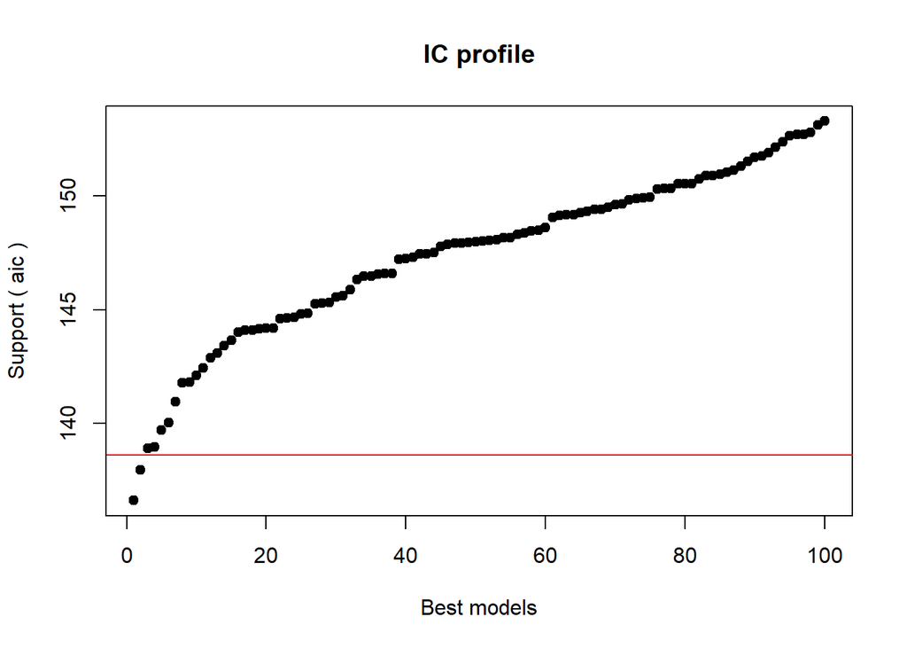

```
Change in best IC: -1.34152159237763 / Change in mean IC: -1.63683917555778

After 40 generations:
Best model: mpg~1+wt+qsec+gear+qsec:hp+qsec:wt+gear:drat+gear:wt
Crit= 136.61102526519
Mean crit= 146.494370090289
```

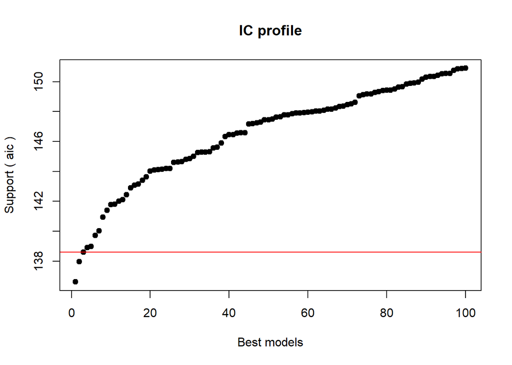

```
Change in best IC: 0 / Change in mean IC: -0.904407079734369

After 50 generations:
Best model: mpg~1+wt+qsec+gear+qsec:hp+qsec:wt+gear:wt
Crit= 136.237445139365
Mean crit= 145.721389786794
```

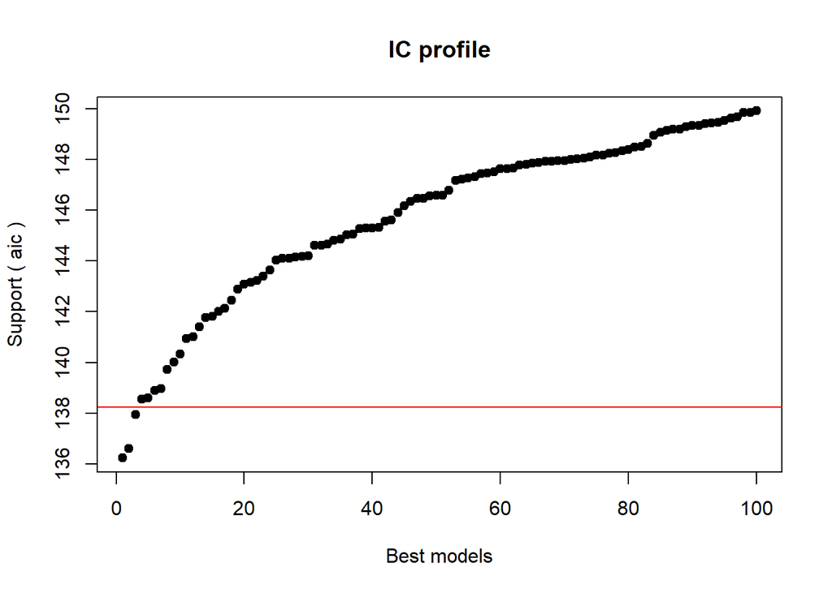

```
Change in best IC: -0.373580125824589 / Change in mean IC: -0.772980303494819

After 60 generations:
Best model: mpg~1+wt+qsec+gear+qsec:hp+qsec:wt+gear:wt
Crit= 136.237445139365
Mean crit= 145.383956733359
```

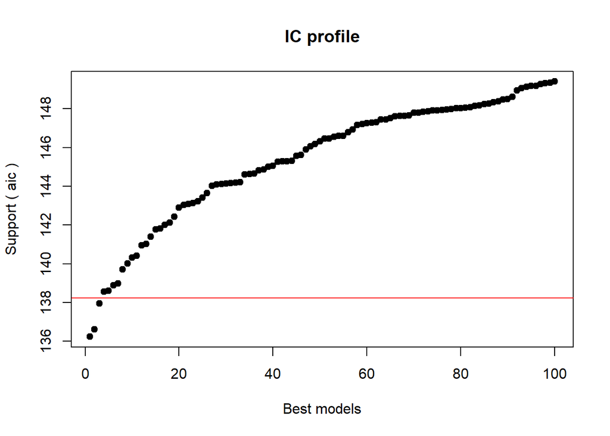

```
Change in best IC: 0 / Change in mean IC: -0.337433053434893

After 70 generations:
Best model: mpg~1+wt+qsec+gear+drat:hp+qsec:wt+gear:wt
Crit= 134.734029151824
Mean crit= 144.930314046032
```

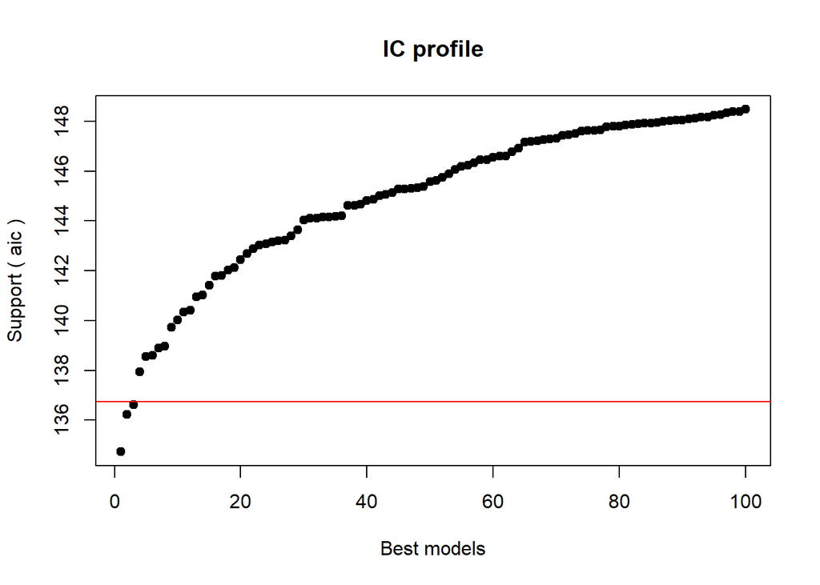

```
Change in best IC: -1.50341598754119 / Change in mean IC: -0.453642687327317

After 80 generations:
Best model: mpg~1+wt+qsec+gear+drat:hp+qsec:wt+gear:wt
Crit= 134.734029151824
Mean crit= 144.494042151362
```

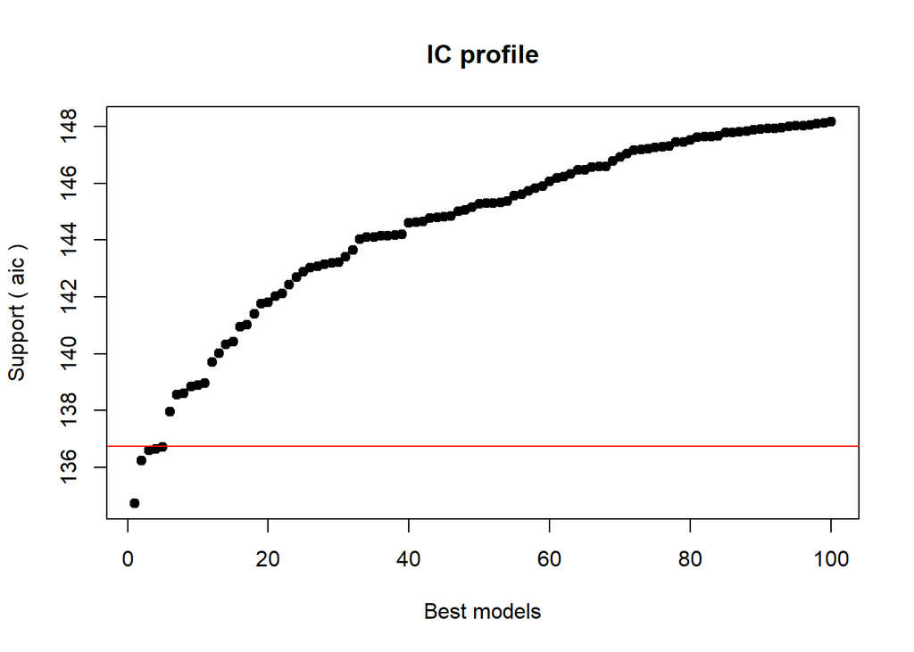

```
Change in best IC: 0 / Change in mean IC: -0.436271894669829

After 90 generations:
Best model: mpg~1+wt+qsec+gear+drat:hp+qsec:wt+gear:wt
Crit= 134.734029151824
Mean crit= 144.285616291053
```

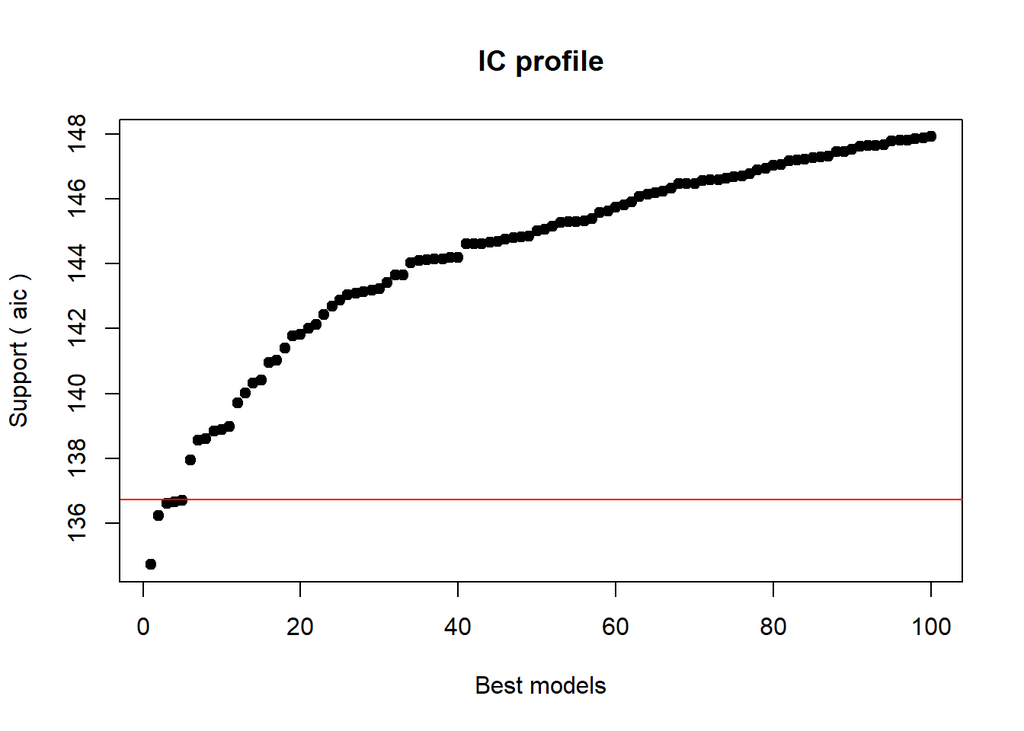

```
Change in best IC: 0 / Change in mean IC: -0.208425860308608

After 100 generations:
Best model: mpg~1+wt+qsec+gear+drat:hp+qsec:wt+gear:wt
Crit= 134.734029151824
Mean crit= 144.086705632512
```

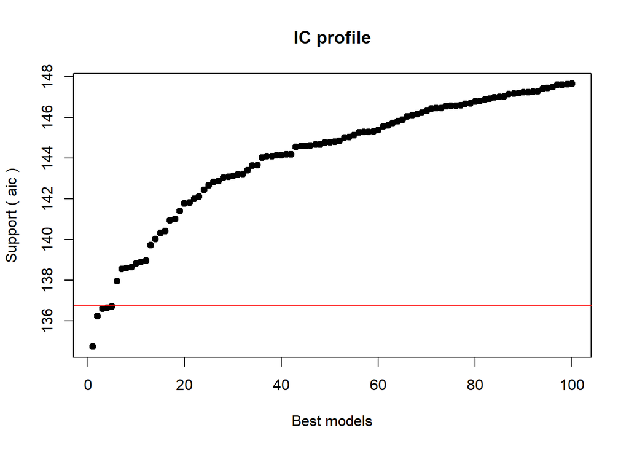

```
Change in best IC: 0 / Change in mean IC: -0.198910658541791

After 110 generations:
Best model: mpg~1+wt+qsec+gear+drat:hp+qsec:wt+gear:wt
Crit= 134.734029151824
Mean crit= 143.845619666556
```

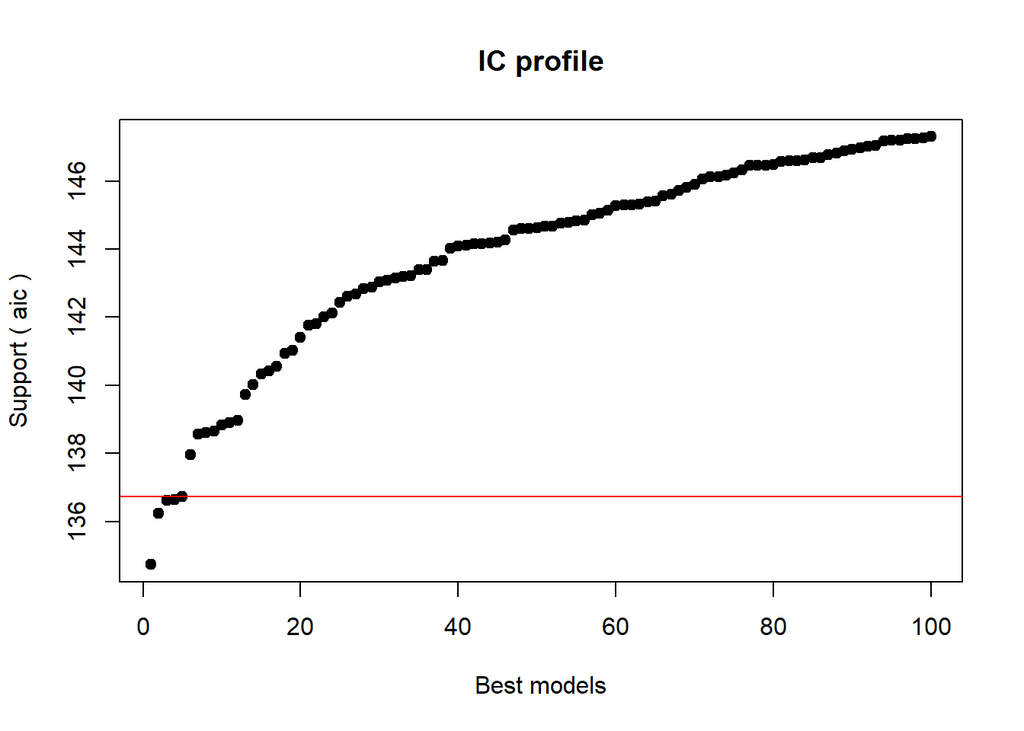

```
Change in best IC: 0 / Change in mean IC: -0.241085965955108

After 120 generations:
Best model: mpg~1+wt+qsec+gear+drat:hp+qsec:wt+gear:wt
Crit= 134.734029151824
Mean crit= 143.769297341986
```

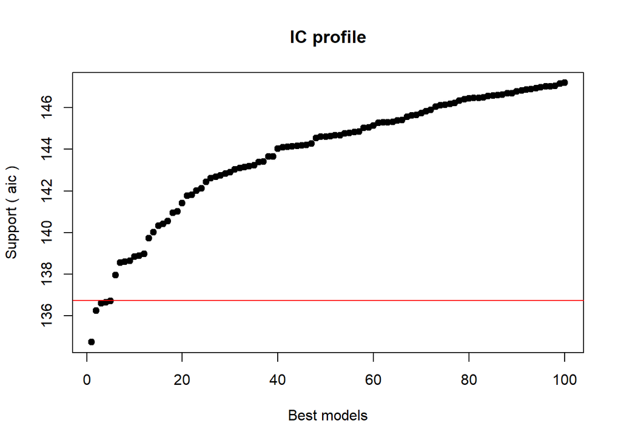

```
Change in best IC: 0 / Change in mean IC: -0.076322324570782

After 130 generations:
Best model: mpg~1+wt+qsec+gear+drat:hp+qsec:wt+gear:wt
Crit= 134.734029151824
Mean crit= 143.698759944009
```

[35 more figures not shown]

[output not shown]

```r
tic()

test_g <- glmulti(mpg ~ hp + drat + wt + qsec + gear,
                 data   = mtcars,
                 method = "g",     # g = genetic algorithms
                 crit   = aic,
                 level  = 2,
                 family = gaussian,
                 fitfunction = glm,
                 confsetsize = 100)
```

```r
toc()
```

```
43.86 sec elapsed
```

# Melhor Modelo

Cumpre recordar que, no início desta exposição, foi apresentada uma análise crítica da seleção sequencial, sugerindo-se que a metodologia disponível dentro do uso do pacote `glmulti` (força bruta e algoritmos genéticos) poderia ser superior. Assim, propõe-se agora uma comparação meticulosa entre os resultados obtidos pelos algoritmos exaustivo e genético e aqueles advindos das técnicas de seleção pra frente (forward) e pra trás (backward), com o intuito de determinar qual estratégia resulta no modelo de análise mais acurado e eficaz.

**Seleção do melhor modelo**

```r
optimal_model_glmulti_exhaustive <- test_h@objects[[1]]
optimal_model_glmulti_genetic    <- test_g@objects[[1]]

compare_performance(
  optimal_model_glmulti_exhaustive,
  optimal_model_glmulti_genetic,
  optimal_model_backward,
  optimal_model_forward
)
```

| Name | Model | AIC | AIC_wt | AICc | AICc_wt | BIC | BIC_wt | R2 | RMSE | Sigma |
| --- | --- | --- | --- | --- | --- | --- | --- | --- | --- | --- |
| optimal_model_glmulti_exhaustive | glm | 134.7340 | 0.391105513 | 140.9949 | 0.4966134913 | 146.4599 | 0.496020832 | 0.9319948 | 1.546943 | 1.750166 |
| optimal_model_glmulti_genetic | glm | 134.7340 | 0.391105513 | 140.9949 | 0.4966134913 | 146.4599 | 0.496020832 | 0.9319948 | 1.546943 | 1.750166 |
| optimal_model_backward | glm | 135.9271 | 0.215385949 | 165.9271 | 0.0000019145 | 157.9132 | 0.001616069 | 0.9544246 | 1.266393 | 1.688524 |
| optimal_model_forward | glm | 144.9185 | 0.002403024 | 149.5852 | 0.0067711030 | 155.1787 | 0.006342268 | 0.9004809 | 1.871356 | 2.076083 |

- Melhor força-bruta:

```r
optimal_model_glmulti_exhaustive$formula
```

```
mpg ~ 1 + wt + qsec + gear + drat:hp + qsec:wt + gear:wt
<environment: 0x000001bcb73baae8>
```

- Melhor algo genético:

```r
optimal_model_glmulti_genetic$formula
```

```
mpg ~ 1 + wt + qsec + gear + drat:hp + qsec:wt + gear:wt
<environment: 0x000001bcb1598080>
```

- Melhor *backward*:

```r
optimal_model_backward$formula
```

```
mpg ~ hp + drat + wt + qsec + gear + hp:drat + hp:wt + hp:qsec +
    hp:gear + drat:wt + drat:qsec + wt:qsec + wt:gear
```

- Melhor *forward*:

```r
optimal_model_forward$formula
```

```
mpg ~ wt + hp + qsec + gear + wt:hp
```

Observa-se que a metodologia implementada pelo pacote `glmulti` resultou em valores inferiores tanto para o Critério de Informação de Akaike (AIC) quanto para o Critério de Informação Bayesiano (BIC), indicando uma eficácia notável. De forma interessante, o coeficiente de determinação (R²) obtido por `glmulti` situa-se medianamente entre os R²s advindos das seleções forward e backward, o que implica que os modelos gerados por `glmulti` não apresentam nem subajuste nem sobreajuste.

Em nosso estudo de caso, os algoritmos exaustivo e genético apresentaram resultados coincidentes (embora isso não seja uma constante) e identificaram três interações (drat:hp + qsec:wt + gear:wt) como significativas. Em contrapartida, a seleção backward indicou oito interações como relevantes, o que pode sugerir um sobreajuste, conforme refletido pelo R² elevado. Por outro lado, a seleção forward apontou apenas uma interação significativa, sugerindo um possível subajuste, em consonância com o R² mais baixo observado.

Assim sendo, almejo ter fornecido argumentos convincentes de que a abordagem `glmulti` supera a seleção Stepwise e culmina na elaboração de um modelo de análise verdadeiramente superior.

A saída de uma análise `glmulti` é um objeto que contém o set de modelos significativos (os 100 melhores modelos por padrão). Funções padrão de regressão do R como `summary()`, `coef()` ou `plot()` podem todas ser usadas para fazer uma inferência multi-modelo. Mas vamos começar com um breve resumo dos resultados que podem ser obtidos por meio do comando `print()`:

```r
print(h_model)
```

```
glmulti.analysis
Method: h / Fitting: glm / IC used: aicc
Level: 2 / Marginality: FALSE
From 100 models:
Best IC: 29793.4306133546
Best model:
[1] "wage ~ 1 + jobclass + education + health + health_ins + age + "
[2] "    education:jobclass + health_ins:education + education:age + "
[3] "    health:age + health_ins:age"
Evidence weight: 0.0786680339413555
Worst IC: 29801.3206286612
6 models within 2 IC units.
74 models to reach 95% of evidence weight.
```

… onde vemos as informações mais importantes, como a função de ajuste, os critérios de informação usados para classificar os modelos, a fórmula do melhor modelo e até o número de modelos que são tão bons quanto o melhor modelo. Existem 6 modelos, que também podemos ver se plotarmos nosso objeto:

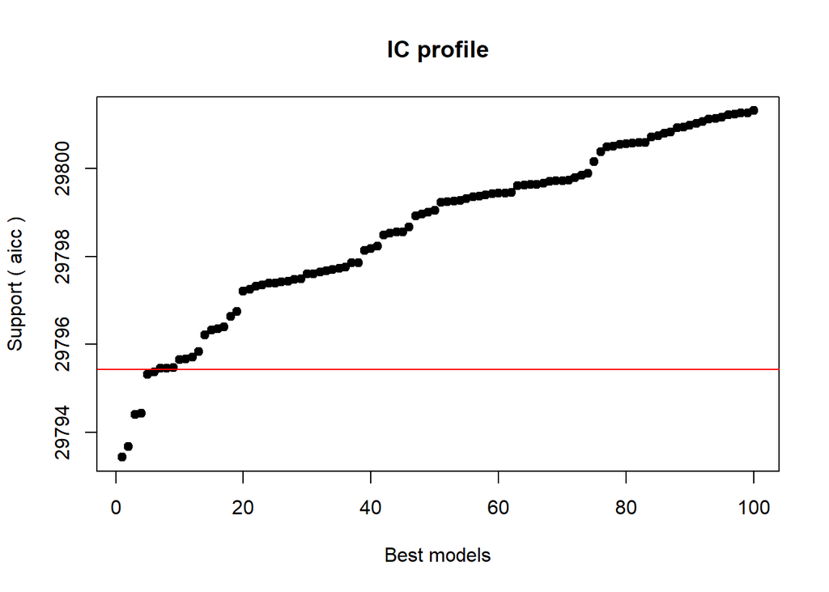

```r
plot(h_model)
```

Este gráfico mostra os valores dos Critérios de Informação (IC) para todos os 100 modelos do set de modelos significativos. Uma linha horizontal separa os 6 melhores modelos, que estão a menos de 2 unidades de IC de distância do MELHOR modelo. Mas quais preditores e interações esses 6 modelos contêm? Utilizando a função `weightable`, podemos exibi-los facilmente:

```r
weightable(h_model)[1:6,] |>
  regulartable() |>       # mostra tabelas mais apresentáveis...
  autofit()
```

| model | aicc | weights |
| --- | --- | --- |
| wage ~ 1 + jobclass + education + health + health_ins + age + education:jobclass + health_ins:education + education:age + health:age + health_ins:age | 29,793.43 | 0.07866803 |
| wage ~ 1 + jobclass + education + health + health_ins + age + education:jobclass + health_ins:education + education:age + health:age | 29,793.68 | 0.06952606 |
| wage ~ 1 + jobclass + education + health_ins + age + education:jobclass + health_ins:education + education:age + health:age | 29,794.40 | 0.04836431 |
| wage ~ 1 + jobclass + education + health_ins + age + education:jobclass + health_ins:education + education:age + health:age + health_ins:age | 29,794.43 | 0.04776916 |
| wage ~ 1 + jobclass + education + health + health_ins + age + education:jobclass + health_ins:education + jobclass:age + education:age + health:age + health_ins:age | 29,795.31 | 0.03070167 |
| wage ~ 1 + jobclass + education + health + health_ins + age + education:jobclass + health_ins:jobclass + health_ins:education + education:age + health:age + health_ins:age | 29,795.36 | 0.02990738 |

Neste momento, apresentamos as equações, os Critérios de Informação e os pesos de Akaike de nossos seis modelos mais destacados. O peso de Akaike de um modelo em particular indica a probabilidade de esse modelo ser o mais acertado entre todos os avaliados, servindo como um indicador de eficiência na minimização da perda de informação. Observa-se que, apesar de o modelo considerado “o melhor” possuir o maior peso, a diferença para o segundo colocado (e os subsequentes) não é significativa. Isso nos leva a questionar se o modelo mais bem classificado é de fato superior aos demais, dado que vários modelos apresentam plausibilidade similar. Surge, portanto, a questão: qual modelo deveríamos adotar?

Diante de seis modelos igualmente competentes, porém com distintas combinações de preditores e interações, identificar os elementos mais relevantes pode ser decisivo na escolha do modelo mais adequado. A função `plot()`, com o parâmetro `type="s"`, facilita essa tarefa ao destacar a relevância dos termos do modelo de forma agregada. A relevância de um preditor ou interação é calculada pela soma dos pesos dos modelos que incluem tal variável. Portanto, uma variável frequente nos modelos de maior peso terá uma relevância elevada. Uma linha vertical em 80% é comumente utilizada para distinguir as variáveis de maior importância, embora esse ponto de corte seja arbitrário. Poderíamos, por exemplo, ajustar esse limite para 50% e considerar para o modelo final todos os preditores e interações com relevância superior a esse percentual.

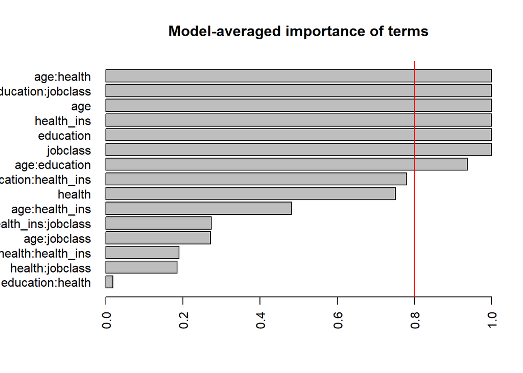

```r
plot(h_model, type = "s")
```

É digno de nota que o modelo inicial já incorpora a interação `age:health_ins`, atribuída com aproximadamente 50% de relevância. Esta escolha seria plenamente justificável. No entanto, considerando a presença de múltiplos termos com uma relevância próxima a 80%, opto por adotar apenas estes, incluindo a interação `education:health_insurance` e o preditor `health`, devido à sua distinta separação dos demais termos. Uma análise dos seis modelos mais eficazes revela que o segundo modelo contém precisamente esses termos. O terceiro modelo é ligeiramente inferior, pois omite a variável `health`, mas, dado que `health` é componente da interação mais significativa - `age:health`, sua inclusão é preferível. Portanto, em vez de aceitar de forma acrítica o modelo preeminente sugerido pelo algoritmo, procedemos a uma avaliação meticulosa dos resultados e decidimos, com base sólida, adotar o segundo modelo como O NOSSO MODELO IDEAL.

Estamos agora em posição de interpretar, visualizar e avaliar as premissas do NOSSO MODELO IDEAL com a diligência habitual.

```r
best_model <- h_model@objects[[2]]

car::Anova(best_model)
```

|  | LR Chisq | Df | Pr(>Chisq) |
| --- | --- | --- | --- |
| jobclass | 4.905955 | 1 | 2.676425e-02 |
| education | 626.206292 | 4 | 3.296884e-134 |
| health | 28.159715 | 1 | 1.117056e-07 |
| health_ins | 158.787137 | 1 | 2.082813e-36 |
| age | 90.943689 | 1 | 1.478195e-21 |
| jobclass:education | 16.139404 | 4 | 2.837697e-03 |
| education:health_ins | 10.219385 | 4 | 3.688995e-02 |
| education:age | 12.107150 | 4 | 1.657200e-02 |
| health:age | 10.129349 | 1 | 1.459269e-03 |

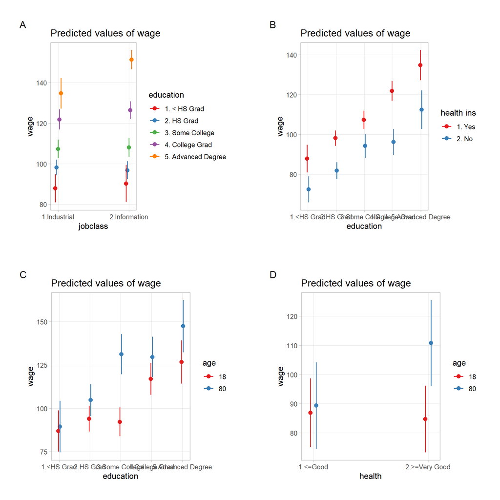

```r
plot_model(best_model, type = "int") |>
  plot_grid()
```

No R temos o pacote `performance` que facilita e muito a investigação das inferências de um modelo de regressão. Vale a pena conhecê-lo um pouco melhor.

# Conclusão

Neste estudo, exploramos metodologias avançadas de seleção de modelos utilizando o pacote `glmulti` no ambiente estatístico R, com o objetivo de identificar o modelo mais adequado para explicar a variação nos salários de trabalhadores americanos. A abordagem de “força bruta”, que considera todas as combinações possíveis de preditores e suas interações, foi comparada com métodos de seleção passo a passo e algoritmos genéticos, revelando insights significativos sobre a adequação e eficácia dos modelos.

A análise exaustiva, embora computacionalmente mais intensiva, mostrou-se uma ferramenta valiosa, capaz de fornecer modelos com valores de Critério de Informação mais precisos, refletindo um equilíbrio entre a complexidade do modelo e a qualidade do ajuste. Por outro lado, o algoritmo genético emergiu como uma alternativa robusta, especialmente útil quando lidamos com um grande número de preditores numéricos, oferecendo resultados quase idênticos em uma fração do tempo.

Curiosamente, a análise revelou que a inclusão de termos altamente multicolineares, como o exemplo do peso e índice de massa corporal (IMC), poderia inflar desnecessariamente a complexidade do modelo sem adicionar valor interpretativo. Isso ressalta a importância de uma seleção criteriosa de preditores para evitar o sobreajuste e garantir a generalização do modelo.

A escolha cuidadosa do nosso modelo ideal, portanto, não foi o resultado de uma aceitação acrítica dos resultados algorítmicos, mas de uma consideração ponderada das evidências estatísticas e da relevância prática. A capacidade de interpretar, visualizar e verificar as premissas do modelo reforça a confiança em sua aplicabilidade e utilidade.

Em suma, este trabalho demonstra que a seleção de modelos, quando conduzida com rigor metodológico e uma compreensão profunda dos dados e das técnicas estatísticas, pode levar a descobertas significativas e modelos robustos, capazes de informar decisões práticas e teóricas no campo da economia laboral.

# References

Siddiqi, Muhammad & Alsayat, Ahmed & Alhwaiti, Yousef & Azad, Mohammad & Alruwaili, Madallah & Alanazi, Saad & Kamruzzaman, MM & Khan, Asfandyar. (2022). *A Precise Medical Imaging Approach for Brain MRI Image Classification.* Computational Intelligence and Neuroscience. 2022. 1-15. 10.1155/2022/6447769. Disponível em [https://www.researchgate.net](https://www.researchgate.net/publication/360323986_A_Precise_Medical_Imaging_Approach_for_Brain_MRI_Image_Classification)

Gujarati, D., N. (2004) **Basic Econometrics**, fourth edition, The McGraw−Hill Companies

Hebbali A (2020). *olsrr: Tools for Building OLS Regression Models*. R package version 0.5.3, https://CRAN.R-project.org/package=olsrr.

Hyndman, R.J., & Athanasopoulos, G. (2021) **Forecasting: principles and practice**, 3rd edition, OTexts: Melbourne, Australia. [OTexts.com/fpp3](https://otexts.com/fpp3/decomposition.html). Accessed on Nov 2023.

Minhas, M., S. *Techniques for handling underfitting and overfitting in Machine Learning*, Medium, Jun 5, 2021. Disponível em [medium.com](https://towardsdatascience.com/techniques-for-handling-underfitting-and-overfitting-in-machine-learning-348daa2380b9), Acesso em Out/2023.

Zablotski (2023, Nov. 5). yuzaR-Blog: R package reviews `glmulti` find the best model!. Retrieved from https://yuzar-blog.netlify.app/posts/2022-05-31-glmulti/

## R packages

```r
citation(package = "glmulti")
```

```
  Calcagno V (2020). _glmulti: Model Selection and Multimodel Inference
  Made Easy_. R package version 1.0.8,
  <https://CRAN.R-project.org/package=glmulti>.

A BibTeX entry for LaTeX users is

  @Manual{,
    title = {glmulti: Model Selection and Multimodel Inference Made Easy},
    author = {Vincent Calcagno},
    year = {2020},
    note = {R package version 1.0.8},
    url = {https://CRAN.R-project.org/package=glmulti},
  }
```

```r
# Total timing to compile this Quarto document

Sys.time() - start_time
```

```
Time difference of 3.946595 mins
```